## Questions and follow up

- What happens with the length-weight relationship within year?
- What happens among years?
- There are several fish that were initially captured and then recaptured that day, some with variation between weight.
- Snatch up error variance for length-weight relationship for stochastic simulations.
- Get fecundity from NGPC
- Fix x and y axis labels on figures 1-3
- Start running Fabans model to esitmate *k* and *L*<sub>∞</sub>

Analysis of length weight data for Missouri River Pallid Sturgeon

Data from the Pallid Sturgeon Population Assessment Project (PSPAP) provided by C. Hubert on 4 January 2016.

The objectives of this analysis are to:

1. Estimate *k* and *L*<sub>∞</sub> for upper and lower basin using recaptured Pallid Sturgeon
2. Evaluate Pallid Sturgeon condition over time.
3. Link Pallid Sturgeon condition to fecundity

The primary function of these objectives are to parametrize the individual based growth model and links to fecundity in the population model.

## Data overview

### Spatial extent of the Pallid Sturgeon Captures

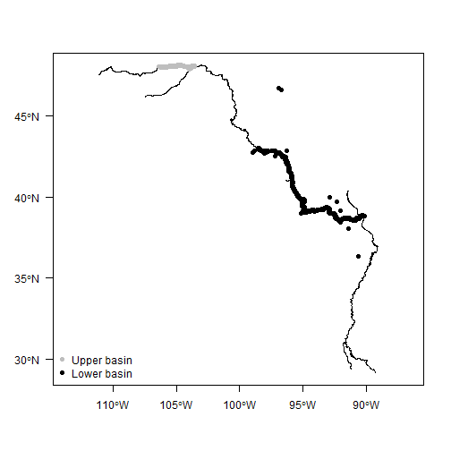

*Figure 1. Spatial extent of Pallid Sturgeon captures and recaptures in the upper and lower Missouri River basins.*

## Pallid Sturgeon Length-Weight Relationship

### Overview

Initially length was modelled using a von Bertalanffy growth function predicting mean length at age. As the model has transitioned to an individual based model, growth (i.e., change in length) will occur on an individual level. This will allow the model to integrate the results of bioenergetic models. A critical aspect of this development is predicting weight from length. The relationship between length and weight also dictates fish condition which may have implications reproductive status.

### Preliminary results

Upper basin Pallid Sturgeon weigh more than similar sized fish from the lower basin (Figure 2). Fitting an allometric scaling equation (*W* = *a* ⋅ *L*<sup>*b*</sup>) were different between the two basins, although differences among years was not evaluated here. See table 1 for preliminary estimates of *a* and *b* for the upper and lower basin for use in the population model.

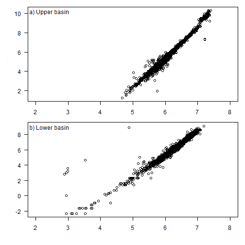

*Figure 2. Relationship of length with weight for upper and lower Missouri River Basin Pallid Sturgeon.*

*Table 1. Estimated a and b parameters for upper and lower Missouri River Pallid Sturgeon. Values in parentheses are 95% confidence intervals.*

| Basin | a | b |
| --- | --- | --- |
| Upper | -6.12(-6.153,-6.087) | 3.24(3.227,3.252) |
| Lower | -5.376(-5.42,-5.333) | 2.96(2.944,2.976) |

## Pallid Sturgeon Condition

### Overview

Pallid Sturgeon condition was calculated as *K*<sub>*n*</sub> = *W*/*W*<sub>*s*</sub>, where *K*<sub>*n*</sub> is the relative condition, *W* is the observed weight, and *W*<sub>*s*</sub> is the standard weight. Standard weight was estimated by Shuman et al. (2011) for Pallid Sturgeon as *W*<sub>*s*</sub> = 10<sup>− 6.2561</sup> ⋅ *F**L*<sup>3.2932</sup>, where *W*<sub>*s*</sub> is as described above and *F**L* is fork length in mm.

### Preliminary results

Figure 3 presents Pallid Sturgeon condition since the begining of the PSPAP. Upper basin fish appear to have higher condition than lower basin fish, although it should be recognized that the equation used to calculate relative condition might be basin specific. Overall relative condition is variable in both basins. Patterns in relative condition appear to decline since 2011, however it is unclear what is biological versus statistically significant.

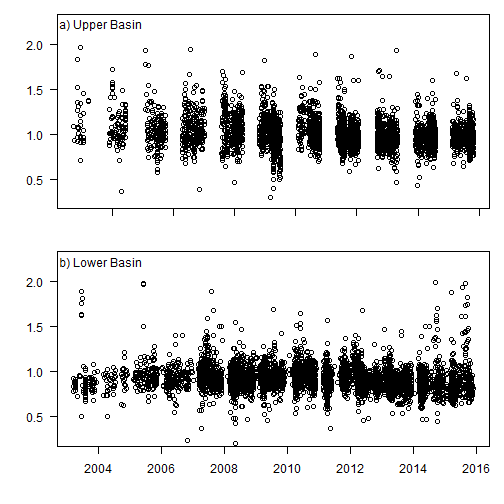

*Figure 3. Estimated relative condition over time for Pallid Sturgeon captured in the upper and lower Missouri River basins.*

## Individual growth

### Overview

Because the model has moved to a individual based framework it makes sense to model growth as individuals rather than as a population von Bertalanffy growth function (vggf). In this analysis we estimated the parameters *k* and *L*<sub>∞</sub> given initial size at capture and size at recapture. Therefore only fish with 2 or more reaptures were used for this analysis. The parameters *k* and *L*<sub>∞</sub> can be estiamted using the Fabans methods and extensions. This approach estimates the change in length over the time at recapture. Is is reasonable because the vbgf, in ordinary differential equation form is *d**L*/*d**t* = *k*(*L*<sub>∞</sub> − *L*<sub>*t*</sub>). There are limitations to this approach resulting in bias that should be recognized. One benefit of this appraoch is that the equation governing the change in length over time is linear, which might allow the analysis to account for among individual variability.

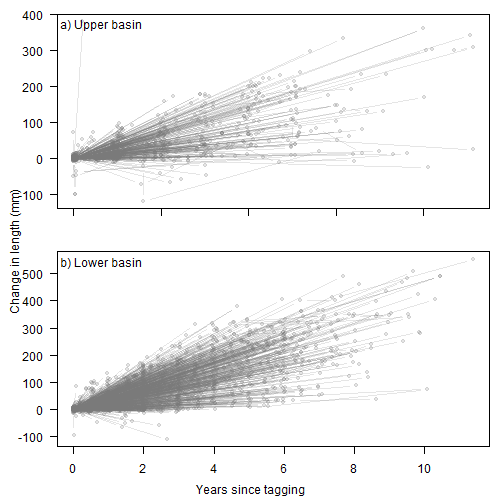

## How precise are lengths of Pallid Sturgeon

The ability to precisely measure length and weight is an important component of monitoring and detecting changes in condition.

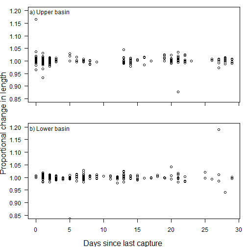

*Figure 5. Plot of proportional change in length for individual Pallid Sturgeon with more than 1 length recorded within 30 days.*

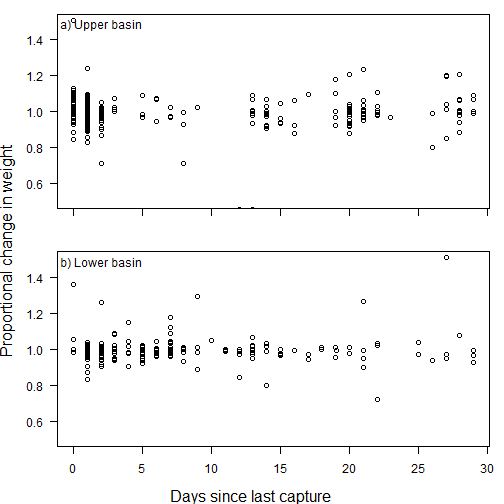

*Figure 6. Plot of proportional change in weight for individual Pallid Sturgeon with more than 1 length recorded within 30 days.* ## Individual Pallid Sturgeon Growth

Using the data for Pallid Sturgeon with 2 or more captures, I fit a Fabens type model to estimate *k* and *L*<sub>∞</sub>. Some data massaging was need to figure out fish with what I assume was data entry errors. Specifically, observations were filtered based on these criteria: 1) change in length over time was constrained to be > 0, 2) Excessively large growth rates were removed (G<0.5 and daily growth < 4). The Fabens model was recast as *L*<sub>2, *i*</sub> = ((*L*<sub>∞</sub> − *L*<sub>1, *i*</sub>) * (1 − *e*<sup>− *k* ⋅ *T*<sub>*i*</sub></sup>)) ⋅ *ϵ*<sub>*i*</sub> where *L*<sub>2</sub> is length at recapture, *L*<sub>1</sub> is length at capture, *L*<sub>∞</sub> is length at infinity, *k* is the how fast length approaches *L*<sub>∞</sub> and *T* is time between capture and recapture in years. A hiearchical model was used allowing *L*<sub>∞</sub> and *k* to vary among individuals as:

*L*<sub>∞, *i*</sub> ∼ *L**o**g**n**o**r**m**a**l*(*μ*<sub>*L*<sub>∞</sub></sub>, *σ*<sub>*L*<sub>∞</sub></sub>)

*k*<sub>*i*</sub> ∼ *L**o**g**n**o**r**m**a**l*(*μ*<sub>*k*</sub>, *σ*<sub>*k*</sub>)

*ϵ*<sub>*i*</sub> ∼ *L**o**g**n**o**r**m**a**l*(1, *σ*)

Fitting the model in JAGS resulted in (preliminary)

Lower basin-

- *L*<sub>∞</sub> ∼ *L**o**g**n**o**r**m**a**l*(1180, 0.05)
- *k* ∼ *L**o**g**n**o**r**m**a**l*(0.05, 1)
- *ϵ* ∼ *L**o**g**n**o**r**m**a**l*(1, 0.003)

To do: 1. Account for *L*<sub>∞</sub> and *k* should be nested within same fish 2. Correlation of *L*<sub>∞</sub> and *k*?

Styled with knitrBootstrap